# Fire up graphlab create

```python
import graphlab
```

# Load some house sales data

Dataset is from house sales in King County, the region where the city of Seattle, WA is located.

```python
sales = graphlab.SFrame('data/home_data.gl/')
```

[output not shown]

```python
sales
```

| id | date | price | bedrooms | bathrooms | sqft_living | sqft_lot | floors | waterfront |
| --- | --- | --- | --- | --- | --- | --- | --- | --- |
| 7129300520 | 2014-10-13 00:00:00+00:00 | 221900 | 3 | 1 | 1180 | 5650 | 1 | 0 |
| 6414100192 | 2014-12-09 00:00:00+00:00 | 538000 | 3 | 2.25 | 2570 | 7242 | 2 | 0 |
| 5631500400 | 2015-02-25 00:00:00+00:00 | 180000 | 2 | 1 | 770 | 10000 | 1 | 0 |
| 2487200875 | 2014-12-09 00:00:00+00:00 | 604000 | 4 | 3 | 1960 | 5000 | 1 | 0 |
| 1954400510 | 2015-02-18 00:00:00+00:00 | 510000 | 3 | 2 | 1680 | 8080 | 1 | 0 |
| 7237550310 | 2014-05-12 00:00:00+00:00 | 1225000 | 4 | 4.5 | 5420 | 101930 | 1 | 0 |
| 1321400060 | 2014-06-27 00:00:00+00:00 | 257500 | 3 | 2.25 | 1715 | 6819 | 2 | 0 |
| 2008000270 | 2015-01-15 00:00:00+00:00 | 291850 | 3 | 1.5 | 1060 | 9711 | 1 | 0 |
| 2414600126 | 2015-04-15 00:00:00+00:00 | 229500 | 3 | 1 | 1780 | 7470 | 1 | 0 |
| 3793500160 | 2015-03-12 00:00:00+00:00 | 323000 | 3 | 2.5 | 1890 | 6560 | 2 | 0 |

| view | condition | grade | sqft_above | sqft_basement | yr_built | yr_renovated | zipcode | lat |
| --- | --- | --- | --- | --- | --- | --- | --- | --- |
| 0 | 3 | 7 | 1180 | 0 | 1955 | 0 | 98178 | 47.51123398 |
| 0 | 3 | 7 | 2170 | 400 | 1951 | 1991 | 98125 | 47.72102274 |
| 0 | 3 | 6 | 770 | 0 | 1933 | 0 | 98028 | 47.73792661 |
| 0 | 5 | 7 | 1050 | 910 | 1965 | 0 | 98136 | 47.52082 |
| 0 | 3 | 8 | 1680 | 0 | 1987 | 0 | 98074 | 47.61681228 |
| 0 | 3 | 11 | 3890 | 1530 | 2001 | 0 | 98053 | 47.65611835 |
| 0 | 3 | 7 | 1715 | 0 | 1995 | 0 | 98003 | 47.30972002 |
| 0 | 3 | 7 | 1060 | 0 | 1963 | 0 | 98198 | 47.40949984 |
| 0 | 3 | 7 | 1050 | 730 | 1960 | 0 | 98146 | 47.51229381 |
| 0 | 3 | 7 | 1890 | 0 | 2003 | 0 | 98038 | 47.36840673 |

| long | sqft_living15 | sqft_lot15 |
| --- | --- | --- |
| -122.25677536 | 1340.0 | 5650.0 |
| -122.3188624 | 1690.0 | 7639.0 |
| -122.23319601 | 2720.0 | 8062.0 |
| -122.39318505 | 1360.0 | 5000.0 |
| -122.04490059 | 1800.0 | 7503.0 |
| -122.00528655 | 4760.0 | 101930.0 |
| -122.32704857 | 2238.0 | 6819.0 |
| -122.31457273 | 1650.0 | 9711.0 |
| -122.33659507 | 1780.0 | 8113.0 |
| -122.0308176 | 2390.0 | 7570.0 |

[21613 rows x 21 columns]  
Note: Only the head of the SFrame is printed.  
You can use print_rows(num_rows=m, num_columns=n) to print more rows and columns.

# Exploring the data for housing sales

The house price is correlated with the number of square feet of living space.

```python
graphlab.canvas.set_target('ipynb')
sales.show(view="Scatter Plot", x="sqft_living", y="price")
```

[output not shown]

# Create a simple regression model of sqft_living to price

Split data into training and testing.  
We use seed=0 so that everyone running this notebook gets the same results. In practice, you may set a random seed (or let GraphLab Create pick a random seed for you).

```python
train_data,test_data = sales.random_split(.8,seed=0)
```

## Build the regression model using only sqft_living as a feature

```python
sqft_model = graphlab.linear_regression.create(train_data, target='price', features=['sqft_living'],validation_set=None)
```

```
PROGRESS: Linear regression:
PROGRESS: --------------------------------------------------------
PROGRESS: Number of examples          : 17384
PROGRESS: Number of features          : 1
PROGRESS: Number of unpacked features : 1
PROGRESS: Number of coefficients    : 2
PROGRESS: Starting Newton Method
PROGRESS: --------------------------------------------------------
PROGRESS: +-----------+----------+--------------+--------------------+---------------+
PROGRESS: | Iteration | Passes   | Elapsed Time | Training-max_error | Training-rmse |
PROGRESS: +-----------+----------+--------------+--------------------+---------------+
PROGRESS: | 1         | 2        | 1.086622     | 4349521.926170     | 262943.613754 |
PROGRESS: +-----------+----------+--------------+--------------------+---------------+
PROGRESS: SUCCESS: Optimal solution found.
PROGRESS:
```

# Evaluate the simple model

```python
print test_data['price'].mean()
```

```
543054.042563
```

```python
print sqft_model.evaluate(test_data)
```

```
{'max_error': 4143550.8825285933, 'rmse': 255191.02870527373}
```

# Let's show what our predictions look like

Matplotlib is a Python plotting library that is also useful for plotting. You can install it with:

'pip install matplotlib'

```python
import matplotlib.pyplot as plt
%matplotlib inline
```

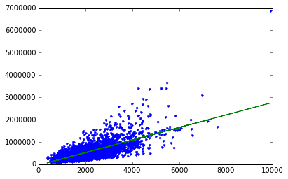

```python
plt.plot(test_data['sqft_living'],test_data['price'],'.',
        test_data['sqft_living'],sqft_model.predict(test_data),'-')
```

Above: blue dots are original data, green line is the prediction from the simple regression.

Below: we can view the learned regression coefficients.

```python
sqft_model.get('coefficients')
```

| name | index | value |
| --- | --- | --- |
| (intercept) | None | -47114.0206702 |
| sqft_living | None | 281.957850166 |

[2 rows x 3 columns]

# Explore other features in the data

To build a more elaborate model, we will explore using more features.

```python
my_features = ['bedrooms', 'bathrooms', 'sqft_living', 'sqft_lot', 'floors', 'zipcode']
```

```python
sales[my_features].show()
```

```python
sales.show(view='BoxWhisker Plot', x='zipcode', y='price')
```

[output not shown]

Pull the bar at the bottom to view more of the data.

98039 is the most expensive zip code.

# Build a regression model with more features

```python
my_features_model = graphlab.linear_regression.create(train_data,target='price',features=my_features,validation_set=None)
```

```
PROGRESS: Linear regression:
PROGRESS: --------------------------------------------------------
PROGRESS: Number of examples          : 17384
PROGRESS: Number of features          : 6
PROGRESS: Number of unpacked features : 6
PROGRESS: Number of coefficients    : 115
PROGRESS: Starting Newton Method
PROGRESS: --------------------------------------------------------
PROGRESS: +-----------+----------+--------------+--------------------+---------------+
PROGRESS: | Iteration | Passes   | Elapsed Time | Training-max_error | Training-rmse |
PROGRESS: +-----------+----------+--------------+--------------------+---------------+
PROGRESS: | 1         | 2        | 0.160860     | 3763208.270524     | 181908.848367 |
PROGRESS: +-----------+----------+--------------+--------------------+---------------+
PROGRESS: SUCCESS: Optimal solution found.
PROGRESS:
```

```python
print my_features_model
```

```
Class                         : LinearRegression

Schema
------
Number of coefficients        : 115
Number of examples            : 17384
Number of feature columns     : 6
Number of unpacked features   : 6

Hyperparameters
---------------
L1 penalty                    : 0.0
L2 penalty                    : 0.01

Training Summary
----------------
Solver                        : auto
Solver iterations             : 1
Solver status                 : SUCCESS: Optimal solution found.
Training time (sec)           : 0.2438

Settings
--------
Residual sum of squares       : 5.75250973324e+14
Training RMSE                 : 181908.8484

Highest Positive Coefficients
-----------------------------
bathrooms[8]                  : 1741315.8161
zipcode[98039]                : 1162973.0381
bathrooms[5.75]               : 1145716.2212
bathrooms[6]                  : 1040376.2448
bathrooms[6.25]               : 919328.0218

Lowest Negative Coefficients
----------------------------
bedrooms[10]                  : -619048.4872
bedrooms[9]                   : -432903.5217
bedrooms[7]                   : -370367.5463
bedrooms[8]                   : -343106.5202
bathrooms[7.5]                : -294326.7393
```

## Comparing the results of the simple model with adding more features

```python
print sqft_model.evaluate(test_data)
print my_features_model.evaluate(test_data)
```

```
{'max_error': 4143550.8825285933, 'rmse': 255191.02870527373}
{'max_error': 3486584.5093818405, 'rmse': 179542.4333126907}
```

# Apply learned models to predict prices of 3 houses

The first house we will use is considered an "average" house in Seattle.

```python
house1 = sales[sales['id']=='5309101200']
```

```python
house1
```

| id | date | price | bedrooms | bathrooms | sqft_living | sqft_lot | floors | waterfront |
| --- | --- | --- | --- | --- | --- | --- | --- | --- |
| 5309101200 | 2014-06-05 00:00:00+00:00 | 620000 | 4 | 2.25 | 2400 | 5350 | 1.5 | 0 |

| view | condition | grade | sqft_above | sqft_basement | yr_built | yr_renovated | zipcode | lat |
| --- | --- | --- | --- | --- | --- | --- | --- | --- |
| 0 | 4 | 7 | 1460 | 940 | 1929 | 0 | 98117 | 47.67632376 |

| long | sqft_living15 | sqft_lot15 |
| --- | --- | --- |
| -122.37010126 | 1250.0 | 4880.0 |

[? rows x 21 columns]  
Note: Only the head of the SFrame is printed. This SFrame is lazily evaluated.  
You can use len(sf) to force materialization.

[figure not shown]

```python
print house1['price']
```

```
[620000, ... ]
```

```python
print sqft_model.predict(house1)
```

```
[629584.8197281546]
```

```python
print my_features_model.predict(house1)
```

```
[721918.9333272849]
```

In this case, the model with more features provides a worse prediction than the simpler model with only 1 feature. However, on average, the model with more features is better.

## Prediction for a second, fancier house

We will now examine the predictions for a fancier house.

```python
house2 = sales[sales['id']=='1925069082']
```

```python
house2
```

| id | date | price | bedrooms | bathrooms | sqft_living | sqft_lot | floors | waterfront |
| --- | --- | --- | --- | --- | --- | --- | --- | --- |
| 1925069082 | 2015-05-11 00:00:00+00:00 | 2200000 | 5 | 4.25 | 4640 | 22703 | 2 | 1 |

| view | condition | grade | sqft_above | sqft_basement | yr_built | yr_renovated | zipcode | lat |
| --- | --- | --- | --- | --- | --- | --- | --- | --- |
| 4 | 5 | 8 | 2860 | 1780 | 1952 | 0 | 98052 | 47.63925783 |

| long | sqft_living15 | sqft_lot15 |
| --- | --- | --- |
| -122.09722322 | 3140.0 | 14200.0 |

[? rows x 21 columns]  
Note: Only the head of the SFrame is printed. This SFrame is lazily evaluated.  
You can use len(sf) to force materialization.

[figure not shown]

```python
print sqft_model.predict(house2)
```

```
[1261170.4040999683]
```

```python
print my_features_model.predict(house2)
```

```
[1446472.4690774987]
```

In this case, the model with more features provides a better prediction. This behavior is expected here, because this house is more differentiated by features that go beyond its square feet of living space, especially the fact that it's a waterfront house.

## Last house, super fancy

Our last house is a very large one owned by a famous Seattleite.

```python
bill_gates = {'bedrooms':[8],
              'bathrooms':[25],
              'sqft_living':[50000],
              'sqft_lot':[225000],
              'floors':[4],
              'zipcode':['98039'],
              'condition':[10],
              'grade':[10],
              'waterfront':[1],
              'view':[4],
              'sqft_above':[37500],
              'sqft_basement':[12500],
              'yr_built':[1994],
              'yr_renovated':[2010],
              'lat':[47.627606],
              'long':[-122.242054],
              'sqft_living15':[5000],
              'sqft_lot15':[40000]}
```

[figure not shown]

```python
print my_features_model.predict(graphlab.SFrame(bill_gates))
```

[output not shown]

## Question 1

```python
sales['price'].mean()
```

```
540088.1419053348
```

```python
type(sales['price', 'zipcode'])
```

```
graphlab.data_structures.sframe.SFrame
```

```python
help(sales.groupby)
```

[output not shown]

[output cut: 209 more lines]

[output not shown]

```python
dir(sales)
```

[output not shown]

[output cut: 44 more lines]

[output not shown]

```python
help(graphlab.aggregate)
```

[output not shown]

[output cut: 126 more lines]

[output not shown]

```python
import graphlab.aggregate as agg
```

```python
dsp = (sales
        .groupby(key_columns = 'zipcode',
                 operations = {'house.knt' : agg.COUNT(),
                               'price.mean'  : agg.MEAN('price')
                              })
        .topk('price.mean')
#         .show()
      )
dsp
```

| zipcode | price.mean | house.knt |
| --- | --- | --- |
| 98039 | 2160606.6 | 50 |
| 98004 | 1355927.09779 | 317 |
| 98040 | 1194230.00355 | 282 |
| 98112 | 1095499.36803 | 269 |
| 98102 | 901258.238095 | 105 |
| 98109 | 879623.623853 | 109 |
| 98105 | 862825.231441 | 229 |
| 98006 | 859684.763052 | 498 |
| 98119 | 849448.01087 | 184 |
| 98005 | 810164.880952 | 168 |

[10 rows x 3 columns]

## Question 2

```python
sales_sqft_living_2to4K = sales[(sales['sqft_living'] >  2000) &
                                (sales['sqft_living'] <= 4000)]
```

```python
# print sales['sqft_living'].show()
print sales[sales['sqft_living'] <= 1000].num_rows()
print sales[sales['sqft_living'] <= 2000].num_rows()
print sales[sales['sqft_living'] <= 3000].num_rows()
print sales[sales['sqft_living'] <= 4000].num_rows()
print sales_sqft_living_2to4K.num_rows()
print sales_sqft_living_2to4K[['price', 'sqft_living']].head()
print sales.num_rows()
print sales_sqft_living_2to4K.num_rows() * 1.0 / sales.num_rows()
```

```
1494
11712
18531
20830
9118
+---------+-------------+
|  price  | sqft_living |
+---------+-------------+
|  538000 |     2570    |
|  662500 |     3560    |
|  650000 |     2950    |
| 2000000 |     3050    |
|  285000 |     2270    |
|  329000 |     2450    |
|  937000 |     2450    |
|  719000 |     2570    |
|  580500 |     2320    |
|  687500 |     2330    |
+---------+-------------+
[10 rows x 2 columns]

21613
0.421875722945
```

## Question 3

```python
advanced_features = \
[
'bedrooms', 'bathrooms', 'sqft_living', 'sqft_lot', 'floors', 'zipcode',
'condition', # condition of house
'grade', # measure of quality of construction
'waterfront', # waterfront property
'view', # type of view
'sqft_above', # square feet above ground
'sqft_basement', # square feet in basement
'yr_built', # the year built
'yr_renovated', # the year renovated
'lat', 'long', # the lat-long of the parcel
'sqft_living15', # average sq.ft. of 15 nearest neighbors
'sqft_lot15', # average lot size of 15 nearest neighbors
]
```

```python
advanced_features
```

```
['bedrooms',
 'bathrooms',
 'sqft_living',
 'sqft_lot',
 'floors',
 'zipcode',
 'condition',
 'grade',
 'waterfront',
 'view',
 'sqft_above',
 'sqft_basement',
 'yr_built',
 'yr_renovated',
 'lat',
 'long',
 'sqft_living15',
 'sqft_lot15']
```

```python
adv_features_model = graphlab.linear_regression.create(train_data,target='price',
                                                      features=advanced_features,
                                                      validation_set=None)
```

```
PROGRESS: Linear regression:
PROGRESS: --------------------------------------------------------
PROGRESS: Number of examples          : 17384
PROGRESS: Number of features          : 18
PROGRESS: Number of unpacked features : 18
PROGRESS: Number of coefficients    : 127
PROGRESS: Starting Newton Method
PROGRESS: --------------------------------------------------------
PROGRESS: +-----------+----------+--------------+--------------------+---------------+
PROGRESS: | Iteration | Passes   | Elapsed Time | Training-max_error | Training-rmse |
PROGRESS: +-----------+----------+--------------+--------------------+---------------+
PROGRESS: | 1         | 2        | 1.556529     | 3469012.450673     | 154580.940735 |
PROGRESS: +-----------+----------+--------------+--------------------+---------------+
PROGRESS: SUCCESS: Optimal solution found.
PROGRESS:
```

```python
print sqft_model.evaluate(test_data)
print my_features_model.evaluate(test_data)
print adv_features_model.evaluate(test_data)
```

```
{'max_error': 4143550.8825285933, 'rmse': 255191.02870527373}
{'max_error': 3486584.5093818405, 'rmse': 179542.4333126907}
{'max_error': 3556849.413849746, 'rmse': 156831.1168020198}
```

```python
print 179542.4333126907 - 156831.1168020198
```

```
22711.3165107
```